# Finding Similar Board Games

Phil Henrickson

2021-12-12

## What is this analysis?

This notebook is for selecting any boardgame and identifying **its most comparable games using data from boardgamegeek.com**. I use a dimension reduction method (PCA) to learn the main points of variation in data about games from boardgamegee - this gives me a vector with every game’s value on each of the principal components. To find similar games, I compute the distance between all games using the first ten principal components. I use the distance between games to determine their overall similarity. Games that are close to each other are said to be *neighbors*.

This document details a game’s 25 nearest neighbors and illustrate some of the dimensions that make the selected game and its neighbors similar.

## Game Profile: **Pathfinder Arena**

Summary information for the selected game.

| ID | Game | Published | Player Count | Playing Time | UserRatings | Average | GeekRating | Complexity |
| --- | --- | --- | --- | --- | --- | --- | --- | --- |
| 326030 | Pathfinder Arena | 2022 | 2-4 | 80 min | 19 | 8.11 |  |  |

Information on the game’s designers, artists, mechanics and categories. Note: designer and artist features are not used in identifying nearest neighbors.

| Designer(s) | Artist(s) | Categories | Mechanics |
| --- | --- | --- | --- |
| Roberto Tibuzzi | Wayne Reynolds | Fantasy | Action Points |
| Flavio Anzidei |  | Miniatures | Variable Player Powers |
| Giorgio Serafini |  |  | Area Movement |
|  |  |  | Map Deformation |
|  |  |  | Hidden Victory Points |
|  |  |  | Deck Construction |
|  |  |  | Slidepush |

For the full profile of the selected game, go to https://boardgamegeek.com/boardgame/326030

## Most Similar Games to **Pathfinder Arena**

The table below displays the most similar games to Pathfinder Arena using data from boardgamegeek (BGG). The reported similarity score is the (squared) inverse of the Manhattan distance between two games.

**Note:** The analysis does not make use of a game’s number of ratings, average, or geek average, but instead looks only at a game’s categories, mechanics, playing time, player count, and complexity. The current approach for computing the distance weighs each component equally; I plan to explore a change to this in the future by using different measures of distance, as we would reasonably expect some components to be more important than others. I initially relied on Euclidean distance, but in tinkering with the results I have opted to go with the Manhattan distance for now.

| Rank | Similarity | Published | ID | Neighbor | BGGRating | GeekRating | Complexity |
| --- | --- | --- | --- | --- | --- | --- | --- |
| 1 | 50.11 | 2017 | 225317 | Halloween | 6.91 | 5.65 | 2.95 |
| 2 | 49.07 | 2003 | 4741 | Warmachine | 7.29 | 6.11 | 3.51 |
| 3 | 46.48 | 2019 | 164702 | Glorantha: The Gods War | 8.07 | 5.91 | 3.43 |
| 4 | 46.03 | 2004 | 13362 | Warhammer 40,000 (Fourth Edition) | 6.50 | 5.84 | 3.51 |
| 5 | 45.76 | 2004 | 14403 | Warhammer 40,000: Battle for Macragge | 6.64 | 5.67 | 3.00 |
| 6 | 45.75 | 2011 | 104575 | Steam Torpedo: First Contact | 6.17 | 5.62 | 2.43 |
| 7 | 45.47 | 2018 | 227002 | Rise of the Necromancers | 7.48 | 5.73 | 2.30 |
| 8 | 45.43 | 1997 | 5316 | Warhammer Epic 40,000 | 6.62 | 5.77 | 3.18 |
| 9 | 45.11 | 2012 | 129974 | Warhammer 40,000: Dark Vengeance | 7.31 | 5.69 | 3.30 |
| 10 | 45.09 | 2017 | 212958 | Space Freaks | 6.74 | 5.60 | 2.83 |
| 11 | 44.88 | 2003 | 7479 | WarCraft: The Board Game | 6.12 | 5.83 | 2.76 |
| 12 | 44.83 | 2016 | 210271 | Guild Ball: Kick Off! | 7.70 | 5.75 | 3.25 |
| 13 | 44.37 | 2004 | 9829 | Runebound | 6.20 | 5.77 | 2.53 |
| 14 | 43.93 | 2017 | 209538 | Alexandria | 5.69 | 5.53 | 2.40 |
| 15 | 43.38 | 2009 | 34152 | Grind | 6.38 | 5.58 | 2.68 |
| 16 | 43.36 | 2019 | 250664 | Godtear | 8.20 | 5.75 | 2.85 |
| 17 | 43.23 | 2018 | 258244 | Discover: Lands Unknown | 5.90 | 5.67 | 2.34 |
| 18 | 42.93 | 1991 | 5369 | Hordes of the Things | 7.30 | 5.72 | 2.49 |
| 19 | 42.80 | 2013 | 144529 | Theseus: The Dark Orbit | 7.07 | 6.28 | 2.83 |
| 20 | 42.71 | 2009 | 45986 | Stronghold | 7.15 | 6.59 | 3.68 |
| 21 | 42.49 | 1989 | 2287 | Elves, Dwarfs & Dungeonbowl | 6.61 | 5.65 | 2.58 |
| 22 | 42.46 | 2004 | 11159 | Dungeoneer: Haunted Woods of Malthorin | 6.28 | 5.68 | 2.22 |
| 23 | 42.44 | 2018 | 244654 | Wildlands | 7.30 | 6.58 | 2.12 |
| 24 | 42.34 | 2017 | 234521 | Necromunda: Underhive | 7.86 | 5.85 | 3.85 |
| 25 | 42.17 | 2019 | 258148 | Power Rangers: Heroes of the Grid | 8.06 | 5.98 | 2.73 |

## Plotting Comparable Games to **Pathfinder Arena**

Placing the selected game and its nearest neighbors on the first two principal components.

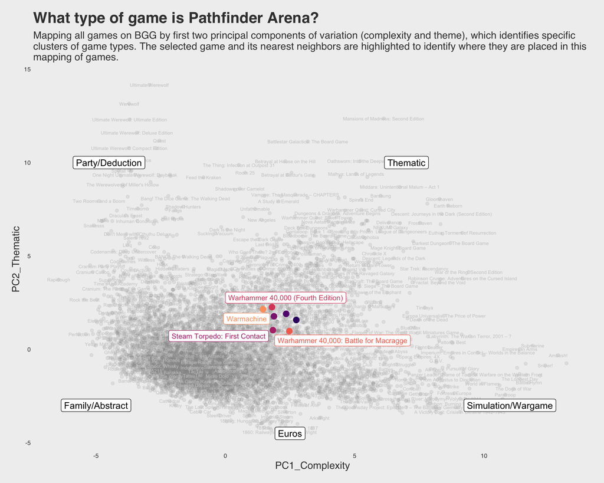

$$\\[0.05in]$$

Placing games on the first four principal components, which I have found to loosely map to complexity, theme, economy, and cooperation.

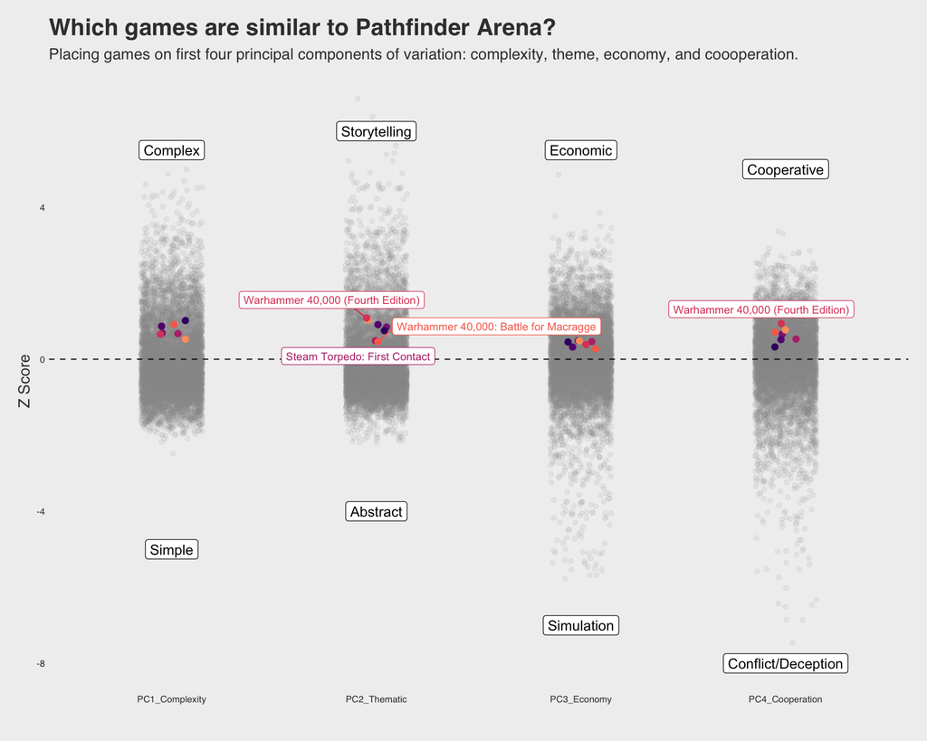

$$\\[0.05in]$$